# Lab3

Exercise 1:

```r
setwd("~/Year 2 Courses/Sem2/DataScience/Week 3")

credit_data <- read.csv("cs-training-NAs-removed.csv")
```

Exercise 2: What is in the first column of the data frame that you created by reading in the CSV file? Do you expect this variable to be useful to predict credit worthiness?

```r
credit_data$X <- NULL
```

Answer: The first column is probably the index. One could even assume that the index shows the order in which the data was gathered. Whilst the index is likely useful for checking whether the independence error assumption is violated, the index has no predictive power. Best to remove it in that case.

Exercise 3: Fit a logistic regression with SeriousDlqin2yrs as dependent variable and MonthlyIncome as the only predictor. Interpret the estimated parameter for MonthlyIncome in plain English. Is the sign (positive versus negative) of this parameter estimate as you would have expected beforehand?

```r
data_logistic <- glm (SeriousDlqin2yrs ~ MonthlyIncome,
                      data = credit_data,
                      family = binomial(link = "logit"))
summary(data_logistic)
```

```
##
## Call:
## glm(formula = SeriousDlqin2yrs ~ MonthlyIncome, family = binomial(link = "logit"),
##     data = credit_data)
##
## Deviance Residuals:
##     Min       1Q   Median       3Q      Max
## -0.4330  -0.4005  -0.3813  -0.3531   5.2293
##
## Coefficients:
##                 Estimate Std. Error z value Pr(>|z|)
## (Intercept)   -2.320e+00  2.007e-02 -115.61   <2e-16 ***
## MonthlyIncome -4.541e-05  2.917e-06  -15.57   <2e-16 ***
## ---
## Signif. codes:  0 '***' 0.001 '**' 0.01 '*' 0.05 '.' 0.1 ' ' 1
##
## (Dispersion parameter for binomial family taken to be 1)
##
##     Null deviance: 60689  on 120268  degrees of freedom
## Residual deviance: 60391  on 120267  degrees of freedom
## AIC: 60395
##
## Number of Fisher Scoring iterations: 6
```

Answer: The negative sign before MonthlyIncome indicates that for every unit increase in MonthlyIncome, we see (the probability of) Serious Delinquency decrease by -4.541*10^(-5). This is what we would have expected, as the more money one makes, the less likely they are to skip out on their debts.

Exercise 4: Consider the model fit from Exercise 3. Create a side-by-side boxplot of the predicted probabilities seperated out by whether the person actually had a serious delinquency (SeriousDlqin2yrs==1) or not. What do you think of the usefulness of this model fit to determine credit worthiness?

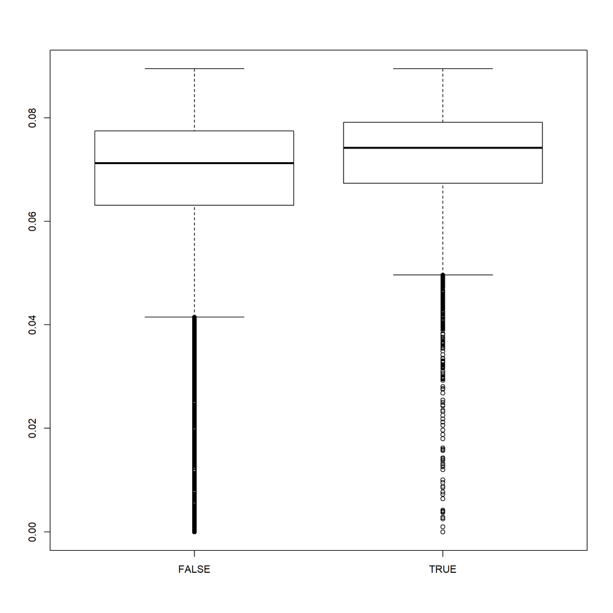

```r
pred <- predict(data_logistic, data = credit_data, type = "response")

boxplot(data = credit_data, pred ~ SeriousDlqin2yrs == 1)
```

Answer: Looking at the two boxplots, we can see that they aren’t all that informative. Both have a median below 8% and there’s not enough separation between the TRUE median and FALSE median. Credit-seekers, according to this model, have a relatively equal probability of being “credit-unworthy”, as they do being worthy. This model wouldn’t really be useful to predict credit worthiness.

Exercise 5: Consider the side-by-side boxplots from Exercise 4. Define SeriousDlqin2yrs == 1 as a positive. Using a probability threshold of 0.5 for classification, how many true positives would you get? How many false positives would you get? How many true negatives will you get? How many false negatives will you get?

```r
summary(credit_data$SeriousDlqin2yrs==1)
```

```
##    Mode   FALSE    TRUE
## logical  111912    8357
```

Answer: When we take a probability threshold of 0.5 for classification, we’ll have no positives (neither true, nor false), because our positives lie below the 0.5 threshold.

True in this case is 8357. False is 111912. Our guess is that the threshold would have to be at least the ratio of these two, in order to get any positive readings, though we’re not 100% sure on that claim. But with a threshold of 0.5:

TP = 0 FP = 0 FN = 8357 TN = 111912

Exercise 6: Plot the ROC curve of the model fit from Exercise 4 and compute the corresponding area under the curve (AUC). Do these results support the answer that you give in Exercise 4 to the question “What do you think of the usefulness of this model fit to determine credit worthiness?” Please explain why or why not.

```r
library(ROCR)
```

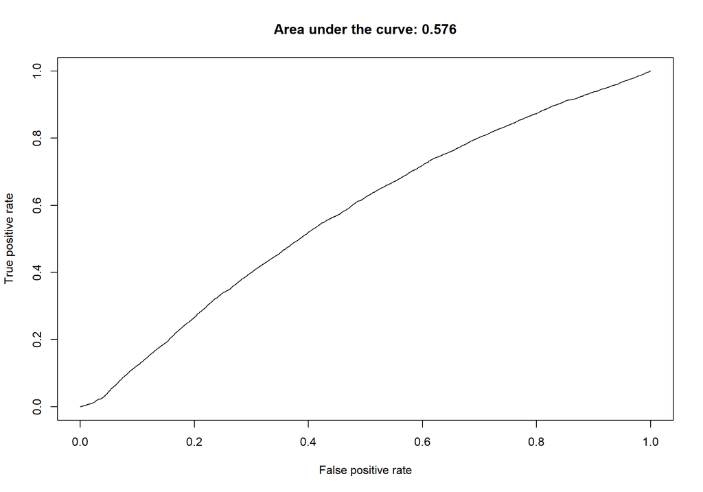

```r
pred = predict(data_logistic, type="response")
predObj = prediction(pred, credit_data$SeriousDlqin2yrs)

rocObj = performance(predObj, measure = "tpr", x.measure = "fpr")
aucObj = performance(predObj, measure = "auc")

plot(rocObj, main = paste("Area under the curve:",
                          round(aucObj@y.values[[1]], 4)))
```

Answer: Yes. The results definitely support our answer in question 4. The model fit is not very useful in predicting credit worthiness. The curve, for one, is almost linear, meaning that whatever we take our true positive rate to be, our false positive will be almost equivalent. This is only a little better than random assignment. And having the “almost same” amount of true positives and false positives is not particularly useful data.

Exercise 7: Fit a logistic regression with SeriousDlqin2yrs as dependent variable and as predictor all other variables in the dataset. Plot the ROC curve and compute the AUC. How do the ROC curve and AUC compare to the results from Exercise 6? Was this to be expected? Why or why not?

```r
all_data_logistic <- glm (SeriousDlqin2yrs ~ .,
                      data = credit_data,
                      family = binomial(link = "logit"))
summary(all_data_logistic)
```

```
##
## Call:
## glm(formula = SeriousDlqin2yrs ~ ., family = binomial(link = "logit"),
##     data = credit_data)
##
## Deviance Residuals:
##     Min       1Q   Median       3Q      Max
## -3.1639  -0.3988  -0.3268  -0.2647   5.1913
##
## Coefficients:
##                                        Estimate Std. Error z value
## (Intercept)                          -1.472e+00  4.630e-02 -31.801
## RevolvingUtilizationOfUnsecuredLines -5.704e-05  7.700e-05  -0.741
## age                                  -2.517e-02  9.290e-04 -27.093
## NumberOfTime30.59DaysPastDueNotWorse  5.007e-01  1.193e-02  41.977
## DebtRatio                            -1.514e-04  4.887e-05  -3.098
## MonthlyIncome                        -4.214e-05  3.290e-06 -12.809
## NumberOfOpenCreditLinesAndLoans      -5.086e-03  2.727e-03  -1.865
## NumberOfTimes90DaysLate               4.426e-01  1.679e-02  26.365
## NumberRealEstateLoansOrLines          8.428e-02  1.111e-02   7.587
## NumberOfTime60.89DaysPastDueNotWorse -9.067e-01  1.942e-02 -46.699
## NumberOfDependents                    1.035e-01  9.667e-03  10.704
##                                      Pr(>|z|)
## (Intercept)                           < 2e-16 ***
## RevolvingUtilizationOfUnsecuredLines  0.45885
## age                                   < 2e-16 ***
## NumberOfTime30.59DaysPastDueNotWorse  < 2e-16 ***
## DebtRatio                             0.00195 **
## MonthlyIncome                         < 2e-16 ***
## NumberOfOpenCreditLinesAndLoans       0.06220 .
## NumberOfTimes90DaysLate               < 2e-16 ***
## NumberRealEstateLoansOrLines         3.28e-14 ***
## NumberOfTime60.89DaysPastDueNotWorse  < 2e-16 ***
## NumberOfDependents                    < 2e-16 ***
## ---
## Signif. codes:  0 '***' 0.001 '**' 0.01 '*' 0.05 '.' 0.1 ' ' 1
##
## (Dispersion parameter for binomial family taken to be 1)
##
##     Null deviance: 60689  on 120268  degrees of freedom
## Residual deviance: 56019  on 120258  degrees of freedom
## AIC: 56041
##
## Number of Fisher Scoring iterations: 6
```

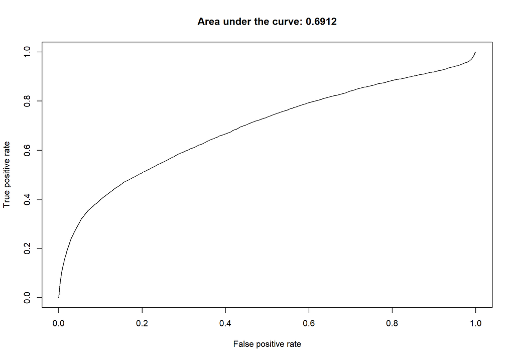

```r
library(ROCR)

pred_all = predict(all_data_logistic, type="response")
predObj_all = prediction(pred_all, credit_data$SeriousDlqin2yrs)

rocObj_all = performance(predObj_all, measure = "tpr", x.measure = "fpr")
aucObj_all = performance(predObj_all, measure = "auc")

plot(rocObj_all, main = paste("Area under the curve:",
                          round(aucObj_all@y.values[[1]], 4)))
```

Answer: With more predictors, we would of course expect a better representation of the data and a better model fit. This model fit is somewhat better, for example here for a true positive rate of 0.5 we have a false positive rate of 0.2, which, depending on your data, on how precise/accurate you’d like to be and on what it is you’re looking for, may or may not be “good enough”.